# Multivariate_Analysis_Juvenile_interpolation_Machine_Learning

#### For the HIP

```python
rf_pipe = Pipeline([
    ("imputer", SimpleImputer(strategy="median")),
        ("rf", RandomForestClassifier(
        n_estimators=200, #Number of trees.
        max_depth=2, #Each tree can only make 2 splits.
        min_samples_leaf=2, #Minimum animals at the end of a branch.
        min_samples_split=4, #Minimum animals to consider a split.
        max_features="sqrt", #Number of features to consider at each split. Random Forest does NOT examine all variables.
        #If every tree always sees all NTs:become very similar. The forest loses diversity. Random feature selection creates more independent trees.
        class_weight="balanced", #Balance the classes.
        random_state=42 #Fixes randomness.
        ))
])

cv = RepeatedStratifiedKFold(
    n_splits=5,
    n_repeats=20,
    random_state=42
)

scores = cross_val_score(
    rf_pipe,
    X_juv_hip_log,
    Y_juv_hip,
    cv=cv,
    scoring="roc_auc",
    n_jobs=-1
)

print("===== Random Forest =====")
print("Fold AUCs:", np.round(rf_scores, 3))
print(f"Mean AUC = {rf_scores.mean():.3f}")
print(f"SD = {rf_scores.std():.3f}")
```

```
===== Random Forest =====
Fold AUCs: [0.417 0.833 1.    0.778 0.667 0.417 0.667 0.5   0.444 0.778 0.583 0.75
 0.917 0.444 0.444 0.583 1.    0.167 0.778 1.    0.667 0.5   0.75  0.778
 0.889 0.583 0.417 0.833 0.889 0.778 0.5   0.917 0.75  1.    1.    0.917
 0.417 0.75  0.444 0.667 0.75  0.75  0.5   0.667 0.889 0.417 0.667 0.75
 0.333 1.    0.583 0.583 0.083 0.889 0.667 0.583 0.833 0.333 0.556 0.333
 1.    0.75  0.333 0.556 0.778 0.583 0.583 0.5   0.889 0.778 0.75  0.75
 0.5   0.889 0.444 0.75  0.667 0.75  0.667 0.667 0.417 0.333 0.583 0.556
 0.778 0.333 0.25  0.667 0.778 0.222 0.167 0.667 0.667 0.667 0.889 0.333
 0.25  0.333 0.444 0.889]
Mean AUC = 0.636
SD = 0.218
```

The Random Forest model achieved a mean ROC-AUC of **0.636 ± 0.218** across 100 repeated stratified cross-validation folds. This indicates that the model performs slightly better than random guessing (AUC = 0.5) The large standard deviation shows that model performance varied considerably between cross-validation splits.

Some folds showed strong discrimination (AUC close to 1.0), while others showed poor performance (AUC below 0.5).This suggests that the model is unstable and that its predictive ability should be interpreted with caution.

```python
rf_pipe.fit(X_juv_hip_log, Y_juv_hip)

rf = rf_pipe.named_steps["rf"]

rf_importance = pd.DataFrame({
    "NT": X_juv_hip_log.columns,
    "Importance": rf.feature_importances_
})

rf_importance = rf_importance.sort_values(
    "Importance",
    ascending=False
).reset_index(drop=True)

print(rf_importance)
```

```
                   NT  Importance
0   Glutamine/Sero d4    0.174340
1                5HTP    0.151314
2                GABA    0.139811
3           Glutamate    0.110836
4            Tyrosine    0.104789
5         Tryptophane    0.071219
6     Normétanéphrine    0.070688
7          Kynurénine    0.054224
8       Noradrénaline    0.037883
9           Adénosine    0.032704
10           Tyramine    0.031325
11         Sérotonine    0.020868
```

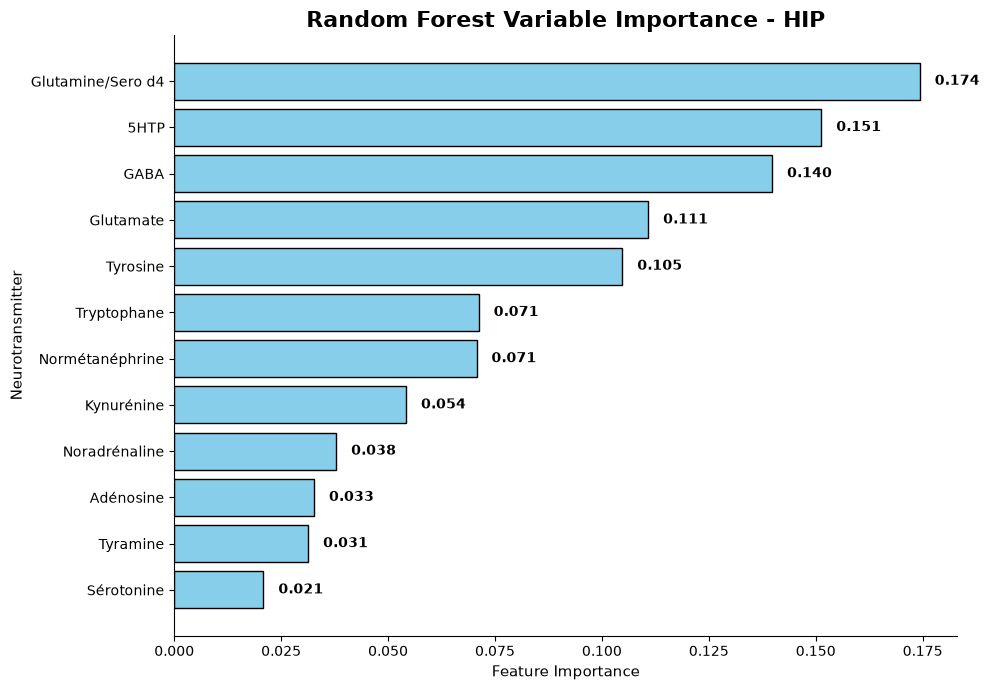

```python
import seaborn as sns
import matplotlib.pyplot as plt

# Sort for horizontal bar order
rf_plot = rf_importance.sort_values(
    "Importance",
    ascending=True
)

fig, ax = plt.subplots(figsize=(10, 7))

bars = ax.barh(
    rf_plot["NT"],
    rf_plot["Importance"],
    color="skyblue",
    edgecolor="black"
)

# Title and labels
ax.set_title(
    "Random Forest Variable Importance - HIP",
    fontsize=16,
    fontweight="semibold"
)

ax.set_xlabel(
    "Feature Importance",
    fontsize=11
)

ax.set_ylabel(
    "Neurotransmitter",
    fontsize=11
)


# Remove unnecessary borders
ax.spines["top"].set_visible(False)
ax.spines["right"].set_visible(False)

# Add importance values
offset = rf_plot["Importance"].max() * 0.02

for bar, value in zip(bars, rf_plot["Importance"]):
    ax.text(
        value + offset,
        bar.get_y() + bar.get_height()/2,
        f"{value:.3f}",
        va="center",
        fontsize=10,
        fontweight="bold"
    )

plt.tight_layout()
plt.show()
```

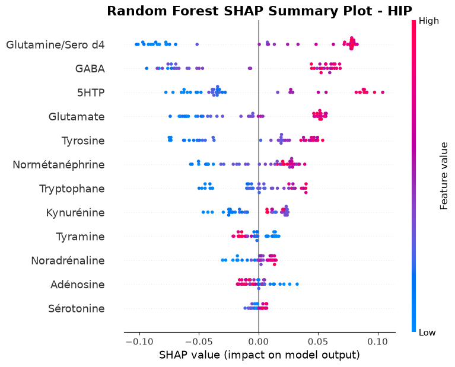

```python
import pandas as pd
import shap
import matplotlib.pyplot as plt


# Impute missing values
X_imp = rf_pipe.named_steps["imputer"].transform(
    X_juv_hip_log
)

X_imp = pd.DataFrame(
    X_imp,
    columns=X_juv_hip_log.columns
)

# Extract tuned RF
rf = rf_pipe.named_steps["rf"]

# SHAP
explainer = shap.TreeExplainer(rf)

shap_values = explainer.shap_values(X_imp)

# Binary classification
shap_class1 = shap_values[:, :, 1]

# Plot
shap.summary_plot(
    shap_class1,
    X_imp,
    show=False
)

plt.title("Random Forest SHAP Summary Plot - HIP", fontsize=16, fontweight="semibold")
plt.tight_layout()
plt.show()
```

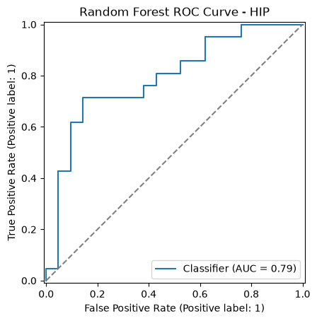

```python
from sklearn.model_selection import StratifiedKFold
from sklearn.model_selection import cross_val_predict
from sklearn.metrics import RocCurveDisplay
import matplotlib.pyplot as plt

cv_roc = StratifiedKFold(
    n_splits=5,
    shuffle=True,
    random_state=42
)

y_prob = cross_val_predict(
    rf_pipe,
    X_juv_hip_log,
    Y_juv_hip,
    cv=cv_roc,
    method="predict_proba"
)[:,1]

RocCurveDisplay.from_predictions(
    Y_juv_hip,
    y_prob
)
plt.plot(
    [0,1],
    [0,1],
    linestyle="--",
    color="grey",
    label="Random classifier"
)

plt.title("Random Forest ROC Curve - HIP")
plt.show()
```

```python
import numpy as np
import pandas as pd

from sklearn.utils import resample

n_boot = 1000

rf_boot = pd.DataFrame(
    columns=X_juv_hip_log.columns
)

for i in range(n_boot):

    # Bootstrap sample
    X_boot, Y_boot = resample(
        X_juv_hip_log,
        Y_juv_hip,
        replace=True,
        random_state=i
    )

    # Fit Random Forest
    rf_pipe.fit(
        X_boot,
        Y_boot
    )

    # Save feature importances
    rf_boot.loc[i] = rf_pipe.named_steps["rf"].feature_importances_
```

```python
rf_summary = pd.DataFrame({
    "Mean": rf_boot.mean(),
    "Lower95": rf_boot.quantile(0.025),
    "Upper95": rf_boot.quantile(0.975)
})

rf_summary = rf_summary.sort_values(
    "Mean",
    ascending=False
)

print(rf_summary)
```

```
                       Mean   Lower95   Upper95
GABA               0.141751  0.042274  0.264389
Glutamine/Sero d4  0.137415  0.041748  0.259653
5HTP               0.131363  0.040708  0.234130
Tyrosine           0.110281  0.028450  0.220484
Glutamate          0.107348  0.033674  0.196584
Tryptophane        0.079444  0.017373  0.188891
Normétanéphrine    0.065210  0.012652  0.168756
Kynurénine         0.059585  0.015048  0.159408
Noradrénaline      0.046539  0.013237  0.113949
Adénosine          0.046213  0.012847  0.114937
Tyramine           0.040439  0.008189  0.116225
Sérotonine         0.034412  0.013932  0.076870
```

#### For the STR

```python
from sklearn.pipeline import Pipeline
from sklearn.impute import SimpleImputer
from sklearn.ensemble import RandomForestClassifier
from sklearn.model_selection import RepeatedStratifiedKFold
from sklearn.model_selection import cross_val_score
import numpy as np

rf_pipe = Pipeline([
    ("imputer", SimpleImputer(strategy="median")),
    ("rf", RandomForestClassifier(
        n_estimators=200,
        max_depth=3,
        min_samples_leaf=2,
        min_samples_split=4,
        class_weight="balanced",
        max_features="sqrt",
        random_state=42
    ))
])

cv = RepeatedStratifiedKFold(
    n_splits=5,
    n_repeats=20,
    random_state=42
)

scores = cross_val_score(
    rf_pipe,
    X_juv_str_log,
    Y_juv_str,
    cv=cv,
    scoring="roc_auc",
    n_jobs=-1
)
print("===== Random Forest =====")
print("Fold AUCs:", np.round(rf_scores, 3))
print(f"Mean AUC = {rf_scores.mean():.3f}")
print(f"SD = {rf_scores.std():.3f}")
```

[output not shown]

However, the relatively large standard deviation indicates variability in performance across different cross-validation splits. Some folds showed strong discrimination (AUC close to 1.0), while others showed poor performance (AUC below 0.5). This variability suggests that the model is sensitive to the specific samples included in each split, and its predictive performance should therefore be interpreted with caution.

```python
rf_pipe.fit(X_juv_str_log, Y_juv_str)

rf = rf_pipe.named_steps["rf"]

# Variable importance
rf_importance = pd.DataFrame({
    "NT": X_juv_str_log.columns,
    "Importance": rf.feature_importances_
})

rf_importance = rf_importance.sort_values(
    by="Importance",
    ascending=False
).reset_index(drop=True)

print(rf_importance)
```

```
                   NT  Importance
0           Glutamate    0.264496
1       Noradrénaline    0.113530
2                5HTP    0.096959
3   Glutamine/Sero d4    0.088855
4            Tyramine    0.077442
5            Tyrosine    0.072598
6     Normétanéphrine    0.055459
7          Kynurénine    0.055167
8         Tryptophane    0.045979
9                GABA    0.045871
10          Adénosine    0.043880
11         Sérotonine    0.039763
```

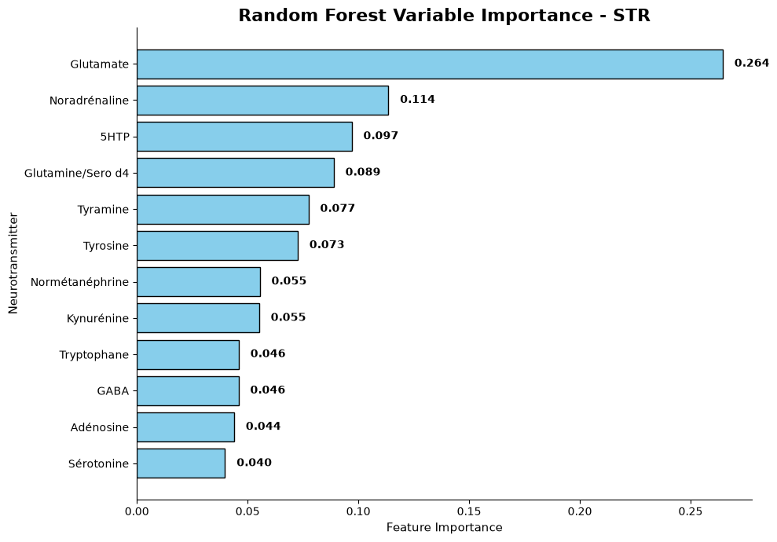

```python
import seaborn as sns
import matplotlib.pyplot as plt

# Sort for horizontal bar order
rf_plot = rf_importance.sort_values(
    "Importance",
    ascending=True
)

fig, ax = plt.subplots(figsize=(10, 7))

bars = ax.barh(
    rf_plot["NT"],
    rf_plot["Importance"],
    color="skyblue",
    edgecolor="black"
)

# Title and labels
ax.set_title(
    "Random Forest Variable Importance - STR",
    fontsize=16,
    fontweight="semibold"
)

ax.set_xlabel(
    "Feature Importance",
    fontsize=11
)

ax.set_ylabel(
    "Neurotransmitter",
    fontsize=11
)


# Remove unnecessary borders
ax.spines["top"].set_visible(False)
ax.spines["right"].set_visible(False)

# Add importance values
offset = rf_plot["Importance"].max() * 0.02

for bar, value in zip(bars, rf_plot["Importance"]):
    ax.text(
        value + offset,
        bar.get_y() + bar.get_height()/2,
        f"{value:.3f}",
        va="center",
        fontsize=10,
        fontweight="bold"
    )

plt.tight_layout()
plt.show()
```

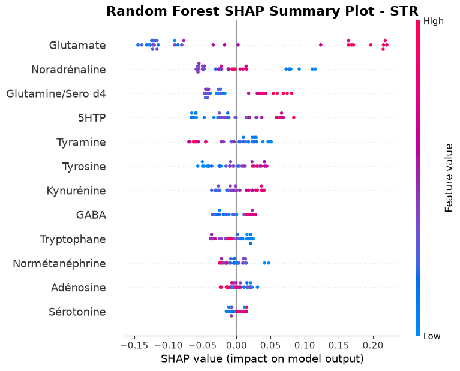

```python
import pandas as pd
import shap
import matplotlib.pyplot as plt


# Impute missing values
X_imp = rf_pipe.named_steps["imputer"].transform(
    X_juv_str_log
)

X_imp = pd.DataFrame(
    X_imp,
    columns=X_juv_str_log.columns
)

# Extract tuned RF
rf = rf_pipe.named_steps["rf"]

# SHAP
explainer = shap.TreeExplainer(rf)

shap_values = explainer.shap_values(X_imp)

# Binary classification
shap_class1 = shap_values[:, :, 1]

# Plot
shap.summary_plot(
    shap_class1,
    X_imp,
    show=False
)

plt.title("Random Forest SHAP Summary Plot - STR", fontsize=16, fontweight="semibold")
plt.tight_layout()
plt.show()
```

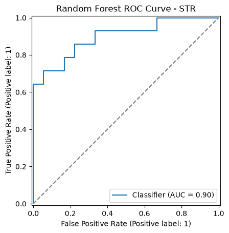

```python
from sklearn.model_selection import StratifiedKFold
from sklearn.model_selection import cross_val_predict
from sklearn.metrics import RocCurveDisplay
import matplotlib.pyplot as plt

cv_roc = StratifiedKFold(
    n_splits=5,
    shuffle=True,
    random_state=42
)

y_prob = cross_val_predict(
    rf_pipe,
    X_juv_str_log,
    Y_juv_str,
    cv=cv_roc,
    method="predict_proba"
)[:,1]

RocCurveDisplay.from_predictions(
    Y_juv_str,
    y_prob
)
plt.plot(
    [0,1],
    [0,1],
    linestyle="--",
    color="grey",
    label="Random classifier"
)

plt.title("Random Forest ROC Curve - STR")
plt.show()
```

```python
import numpy as np
import pandas as pd

from sklearn.utils import resample

n_boot = 1000

rf_boot = pd.DataFrame(
    columns=X_juv_str_log.columns
)

for i in range(n_boot):

    # Bootstrap sample
    X_boot, Y_boot = resample(
        X_juv_str_log,
        Y_juv_str,
        replace=True,
        random_state=i
    )

    # Fit Random Forest
    rf_pipe.fit(
        X_boot,
        Y_boot
    )

    # Save feature importances
    rf_boot.loc[i] = rf_pipe.named_steps["rf"].feature_importances_
```

```python
rf_summary = pd.DataFrame({
    "Mean": rf_boot.mean(),
    "Lower95": rf_boot.quantile(0.025),
    "Upper95": rf_boot.quantile(0.975)
})

rf_summary = rf_summary.sort_values(
    "Mean",
    ascending=False
)

print(rf_summary)
```

```
                       Mean   Lower95   Upper95
Glutamate          0.219189  0.110671  0.315877
Noradrénaline      0.113518  0.041334  0.219441
5HTP               0.102960  0.032731  0.221996
Glutamine/Sero d4  0.090263  0.028759  0.192606
Tyrosine           0.081134  0.027834  0.175229
Tyramine           0.075161  0.021887  0.178003
Kynurénine         0.066311  0.022397  0.164743
GABA               0.057063  0.018439  0.137758
Normétanéphrine    0.053688  0.019688  0.107824
Adénosine          0.048522  0.019218  0.113240
Tryptophane        0.046406  0.016583  0.105506
Sérotonine         0.045787  0.019442  0.101296
```

#### Code supplementary for the Random Forest analysis

Here below is the code used to define what the correct value for each hyperparameter is for the Random Forest analysis. The code was used to find the best hyperparameters for the Random Forest model using GridSearchCV. The hyperparameters tuned include the number of trees in the forest (n_estimators), the maximum depth of each tree (max_depth), and the minimum number of samples required to split a node (min_samples_split). The grid search evaluates all combinations of these hyperparameters using cross-validation to identify the combination that yields the best performance based on a specified scoring metric (e.g., accuracy, ROC-AUC).

code supp

from sklearn.pipeline import Pipeline from sklearn.impute import SimpleImputer from sklearn.ensemble import RandomForestClassifier from sklearn.model_selection import GridSearchCV from sklearn.model_selection import RepeatedStratifiedKFold from sklearn.model_selection import cross_val_score import numpy as np

rf_pipe = Pipeline([ ("imputer", SimpleImputer(strategy="median")), ("rf", RandomForestClassifier( class_weight="balanced", random_state=42 )) ])

param_grid = { "rf__n_estimators": [100, 200], "rf__max_depth": [2, 3], "rf__min_samples_leaf": [2, 4], "rf__min_samples_split": [4, 8] }

inner_cv = RepeatedStratifiedKFold( n_splits=5, n_repeats=5, random_state=42 )

grid = GridSearchCV( rf_pipe, param_grid, cv=inner_cv, scoring="roc_auc", n_jobs=-1 )

outer_cv = RepeatedStratifiedKFold( n_splits=5, n_repeats=20, random_state=42 )

scores = cross_val_score( grid, X_juv_pfc_log, # change for HIP or STR Y_juv_pfc, cv=outer_cv, scoring="roc_auc", n_jobs=-1 )

print("===== Tuned Random Forest =====") print(f"Mean AUC = {scores.mean():.3f}") print(f"SD = {scores.std():.3f}")